# MSK and DRACC Cell-Selection Consistency

This report follows the cumulative cell-selection workflow in order: initial called cells, singlets, transcriptome QC, and geneBC/LARRY eligibility.

```r
knitr::opts_chunk$set(
  echo = TRUE,
  message = FALSE,
  warning = FALSE
)

library(ggplot2)

output_dir = "/fh/fast/sun_w/yub/github/MSK_30polyKO/msk_dracc_consistency/outputs/01_compare_cell_selection"
dir.create(output_dir, recursive = TRUE, showWarnings = FALSE)

msk_dir = "/fh/fast/sun_w/yub/github/MSK_30polyKO/external_sources/msk/30KO_scRNAseq"
dracc_dir = "/fh/fast/sun_w/yub/github/MSK_30polyKO/dracc_qc/outputs/01_extract_raw_count_cell_meta"

stage_map = data.frame(
  stage = c(
    "ES", "DE", "DE_GemX", "PP1", "PP2",
    "S5_1", "S5_2", "S6_1", "S6_2"
  ),
  msk_source = c(
    "ES", "DE_XM", "DE_NZ", "PP1", "PP2",
    "S5_1", "S5_2", "S6_1", "S6_2"
  ),
  dracc_source = c(
    "ES", "DE", "DE_XM", "PP1", "PP2",
    "S5_1", "S5_2", "S6_1", "S6_2"
  ),
  stringsAsFactors = FALSE
)
feature_suffix = c(
  ES = "es",
  DE = "de",
  DE_XM = "de_gemx",
  PP1 = "pp1",
  PP2 = "pp2",
  S5_1 = "s5_1",
  S5_2 = "s5_2",
  S6_1 = "s6_1",
  S6_2 = "s6_2"
)
```

## Stage Mapping

The final stage labels align corresponding MSK and DRACC samples. The two DE sources require explicit mapping; the remaining stages map directly.

```r
knitr::kable(stage_map, row.names = FALSE)
```

| stage | msk_source | dracc_source |
| --- | --- | --- |
| ES | ES | ES |
| DE | DE_XM | DE |
| DE_GemX | DE_NZ | DE_XM |
| PP1 | PP1 | PP1 |
| PP2 | PP2 | PP2 |
| S5_1 | S5_1 | S5_1 |
| S5_2 | S5_2 | S5_2 |
| S6_1 | S6_1 | S6_1 |
| S6_2 | S6_2 | S6_2 |

## Initial Called Cells

MSK initial cells are the cells present in its per-stage transcriptome metadata. DRACC initial cells require `is_cell == TRUE`. Comparisons use the 16-base 10x barcode within each mapped stage.

```r
# Compare two cell-barcode sets at one cumulative workflow step.
compare_sets <- function(stage, msk_cells, dracc_cells) {
  shared_cells = intersect(msk_cells, dracc_cells)

  data.frame(
    stage = stage,
    n_msk = length(msk_cells),
    n_dracc = length(dracc_cells),
    n_shared = length(shared_cells),
    shared_over_msk = 100 * length(shared_cells) / length(msk_cells),
    shared_over_dracc = 100 * length(shared_cells) / length(dracc_cells),
    stringsAsFactors = FALSE
  )
}

# Add the overall row to one stage-level cell-set table.
add_overall <- function(x) {
  rbind(
    x,
    data.frame(
      stage = "All",
      n_msk = sum(x$n_msk),
      n_dracc = sum(x$n_dracc),
      n_shared = sum(x$n_shared),
      shared_over_msk = 100 * sum(x$n_shared) / sum(x$n_msk),
      shared_over_dracc = 100 * sum(x$n_shared) / sum(x$n_dracc),
      stringsAsFactors = FALSE
    )
  )
}

# Load the called-cell metadata needed by later cumulative steps.
load_stage <- function(i) {
  map = stage_map[i, , drop = FALSE]
  msk_path = file.path(
    msk_dir,
    "3.TX_QC",
    paste0("df.", map$msk_source, ".seu.QC.metadata.rds")
  )
  msk_bc_path = file.path(
    msk_dir,
    "2.demulti_BC",
    paste0("df.all.larryBC.geneBC.", map$msk_source, ".rds")
  )
  dracc_path = file.path(
    dracc_dir,
    paste0(map$dracc_source, ".rds")
  )

  stopifnot(
    file.exists(msk_path),
    file.exists(msk_bc_path),
    file.exists(dracc_path)
  )

  msk = as.data.frame(readRDS(msk_path), stringsAsFactors = FALSE)
  msk_bc = as.data.frame(readRDS(msk_bc_path), stringsAsFactors = FALSE)
  dracc = as.data.frame(readRDS(dracc_path), stringsAsFactors = FALSE)
  stopifnot(
    all(c(
      "scDblFinder.class",
      "scDblFinder.score",
      "nCount_RNA",
      "nFeature_RNA",
      "percent_mito"
    ) %in% colnames(msk)),
    all(c(
      "cellid",
      "geneBC",
      "geneBCCategory",
      "larryBC",
      "larryBCCategory",
      "larryBC_type"
    ) %in% colnames(msk_bc)),
    all(c(
      "is_cell",
      "dracc_barcode",
      "singlet",
      "doublet",
      "doublet_scores",
      "total_counts",
      "n_genes",
      "mt_pct"
    ) %in% colnames(dracc))
  )

  msk$barcode = substr(rownames(msk), 1, 16)
  msk_bc$barcode = substr(as.character(msk_bc$cellid), 1, 16)
  stopifnot(is.logical(dracc$is_cell), !anyNA(dracc$is_cell))
  dracc = dracc[dracc$is_cell, , drop = FALSE]

  stopifnot(
    !anyNA(msk$barcode),
    !anyNA(msk_bc$barcode),
    !anyNA(dracc$dracc_barcode),
    !anyDuplicated(msk$barcode),
    !anyDuplicated(msk_bc$barcode),
    !anyDuplicated(dracc$dracc_barcode)
  )

  suffix = feature_suffix[[map$dracc_source]]
  guide_prefix = paste0("CRISPR_Guide_Capture_grna_", suffix)
  larry_prefix = paste0("Custom_larry_", suffix)
  guide_fields = c(
    "__num_umis",
    "__feature_call",
    "__feature1_count",
    "__feature2_count"
  )
  larry_fields = c(
    "__feature_call",
    "__feature1_count",
    "__feature2_count"
  )
  stopifnot(
    all(paste0(guide_prefix, guide_fields) %in% colnames(dracc)),
    all(paste0(larry_prefix, larry_fields) %in% colnames(dracc))
  )

  list(
    stage = map$stage,
    msk = msk,
    msk_bc = msk_bc,
    dracc = dracc,
    guide_prefix = guide_prefix,
    larry_prefix = larry_prefix
  )
}

stage_data = lapply(seq_len(nrow(stage_map)), load_stage)

initial_table = do.call(
  rbind,
  lapply(stage_data, function(x) {
    compare_sets(
      x$stage,
      x$msk$barcode,
      as.character(x$dracc$dracc_barcode)
    )
  })
)
initial_table = add_overall(initial_table)

write.csv(
  initial_table,
  file.path(output_dir, "initial_called_cells.csv"),
  row.names = FALSE
)

knitr::kable(
  initial_table,
  row.names = FALSE,
  digits = c(NA, 0, 0, 0, 2, 2),
  col.names = c(
    "Stage", "MSK", "DRACC", "Shared",
    "Shared/MSK (%)", "Shared/DRACC (%)"
  )
)
```

| Stage | MSK | DRACC | Shared | Shared/MSK (%) | Shared/DRACC (%) |
| --- | --- | --- | --- | --- | --- |
| ES | 32670 | 33236 | 32658 | 99.96 | 98.26 |
| DE | 32256 | 33123 | 32253 | 99.99 | 97.37 |
| DE_GemX | 42991 | 43352 | 42630 | 99.16 | 98.33 |
| PP1 | 11446 | 13261 | 11446 | 100.00 | 86.31 |
| PP2 | 26805 | 26394 | 26090 | 97.33 | 98.85 |
| S5_1 | 31974 | 29096 | 29030 | 90.79 | 99.77 |
| S5_2 | 32170 | 33253 | 32168 | 99.99 | 96.74 |
| S6_1 | 24607 | 25435 | 24607 | 100.00 | 96.74 |
| S6_2 | 25521 | 23078 | 22117 | 86.66 | 95.84 |
| All | 260440 | 260228 | 252999 | 97.14 | 97.22 |

## Singlets

Each pipeline’s own doublet classification is applied to its initial called cells. Raw scores are compared only for common initial cells because their numerical scales are pipeline-specific.

```r
stage_data = lapply(stage_data, function(x) {
  x$msk$pass_singlet = (
    !is.na(x$msk$scDblFinder.class) &
      x$msk$scDblFinder.class == "singlet"
  )
  stopifnot(is.logical(x$dracc$singlet), !anyNA(x$dracc$singlet))
  x$dracc$pass_singlet = x$dracc$singlet
  x
})

singlet_table = do.call(
  rbind,
  lapply(stage_data, function(x) {
    compare_sets(
      x$stage,
      x$msk$barcode[x$msk$pass_singlet],
      as.character(x$dracc$dracc_barcode[x$dracc$pass_singlet])
    )
  })
)
singlet_table = add_overall(singlet_table)

write.csv(
  singlet_table,
  file.path(output_dir, "singlet_cells.csv"),
  row.names = FALSE
)

knitr::kable(
  singlet_table,
  row.names = FALSE,
  digits = c(NA, 0, 0, 0, 2, 2),
  col.names = c(
    "Stage", "MSK", "DRACC", "Shared",
    "Shared/MSK (%)", "Shared/DRACC (%)"
  )
)
```

| Stage | MSK | DRACC | Shared | Shared/MSK (%) | Shared/DRACC (%) |
| --- | --- | --- | --- | --- | --- |
| ES | 26752 | 27489 | 25995 | 97.17 | 94.57 |
| DE | 25096 | 25544 | 24233 | 96.56 | 94.87 |
| DE_GemX | 36735 | 35164 | 33874 | 92.21 | 96.33 |
| PP1 | 9905 | 11364 | 9228 | 93.17 | 81.20 |
| PP2 | 20252 | 21128 | 19295 | 95.27 | 91.32 |
| S5_1 | 25324 | 23934 | 22115 | 87.33 | 92.40 |
| S5_2 | 25784 | 27375 | 25260 | 97.97 | 92.27 |
| S6_1 | 19456 | 21293 | 18961 | 97.46 | 89.05 |
| S6_2 | 20279 | 19095 | 16532 | 81.52 | 86.58 |
| All | 209583 | 212386 | 195493 | 93.28 | 92.05 |

### Doublet Diagnostics

The call table distinguishes matched singlets, matched doublets, and the two directions of disagreement. Doublet-overlap enrichment compares the observed number called doublet by both pipelines with the overlap expected from their two marginal doublet rates. Stage tests use one-sided hypergeometric p-values with BH adjustment across the nine stages.

```r
# Align doublet scores and calls for common initial cells.
doublet_data = do.call(
  rbind,
  lapply(stage_data, function(x) {
    common_cells = intersect(
      x$msk$barcode,
      as.character(x$dracc$dracc_barcode)
    )
    msk_index = match(common_cells, x$msk$barcode)
    dracc_index = match(common_cells, x$dracc$dracc_barcode)

    data.frame(
      stage = x$stage,
      barcode = common_cells,
      msk_score = as.numeric(x$msk$scDblFinder.score[msk_index]),
      dracc_score = as.numeric(x$dracc$doublet_scores[dracc_index]),
      msk_call = as.character(x$msk$scDblFinder.class[msk_index]),
      dracc_call = ifelse(
        as.logical(x$dracc$doublet[dracc_index]),
        "doublet",
        ifelse(
          as.logical(x$dracc$singlet[dracc_index]),
          "singlet",
          NA_character_
        )
      ),
      stringsAsFactors = FALSE
    )
  })
)
doublet_data = doublet_data[complete.cases(doublet_data), , drop = FALSE]
stopifnot(
  all(doublet_data$msk_call %in% c("singlet", "doublet")),
  all(doublet_data$dracc_call %in% c("singlet", "doublet"))
)

# Summarize paired score and call agreement for one stage or all stages.
summarize_doublets <- function(x, stage) {
  data.frame(
    stage = stage,
    n_common = nrow(x),
    both_singlet = sum(
      x$msk_call == "singlet" & x$dracc_call == "singlet"
    ),
    both_doublet = sum(
      x$msk_call == "doublet" & x$dracc_call == "doublet"
    ),
    msk_doublet_dracc_singlet = sum(
      x$msk_call == "doublet" & x$dracc_call == "singlet"
    ),
    msk_singlet_dracc_doublet = sum(
      x$msk_call == "singlet" & x$dracc_call == "doublet"
    ),
    agreement = 100 * mean(x$msk_call == x$dracc_call),
    score_spearman = cor(x$msk_score, x$dracc_score, method = "spearman"),
    stringsAsFactors = FALSE
  )
}

doublet_call_table = do.call(
  rbind,
  c(
    lapply(stage_map$stage, function(stage) {
      summarize_doublets(
        doublet_data[doublet_data$stage == stage, , drop = FALSE],
        stage
      )
    }),
    list(summarize_doublets(doublet_data, "All"))
  )
)

write.csv(
  doublet_call_table,
  file.path(output_dir, "doublet_call_agreement.csv"),
  row.names = FALSE
)

knitr::kable(
  doublet_call_table,
  row.names = FALSE,
  digits = c(NA, 0, 0, 0, 0, 0, 2, 3),
  col.names = c(
    "Stage", "Common", "Both singlet", "Both doublet",
    "MSK doublet / DRACC singlet",
    "MSK singlet / DRACC doublet",
    "Agreement (%)", "Score Spearman"
  )
)
```

| Stage | Common | Both singlet | Both doublet | MSK doublet / DRACC singlet | MSK singlet / DRACC doublet | Agreement (%) | Score Spearman |
| --- | --- | --- | --- | --- | --- | --- | --- |
| ES | 32658 | 25995 | 5002 | 916 | 745 | 94.91 | 0.856 |
| DE | 32253 | 24233 | 6719 | 441 | 860 | 95.97 | 0.857 |
| DE_GemX | 42630 | 33874 | 5688 | 568 | 2500 | 92.80 | 0.807 |
| PP1 | 11446 | 9228 | 1214 | 327 | 677 | 91.23 | 0.773 |
| PP2 | 26090 | 19295 | 5021 | 1529 | 245 | 93.20 | 0.904 |
| S5_1 | 29030 | 22115 | 4896 | 1753 | 266 | 93.05 | 0.876 |
| S5_2 | 32168 | 25260 | 5356 | 1030 | 522 | 95.18 | 0.893 |
| S6_1 | 24607 | 18961 | 3646 | 1505 | 495 | 91.87 | 0.886 |
| S6_2 | 22117 | 16532 | 3637 | 1602 | 346 | 91.19 | 0.845 |
| All | 252999 | 195493 | 41179 | 9671 | 6656 | 93.55 | 0.841 |

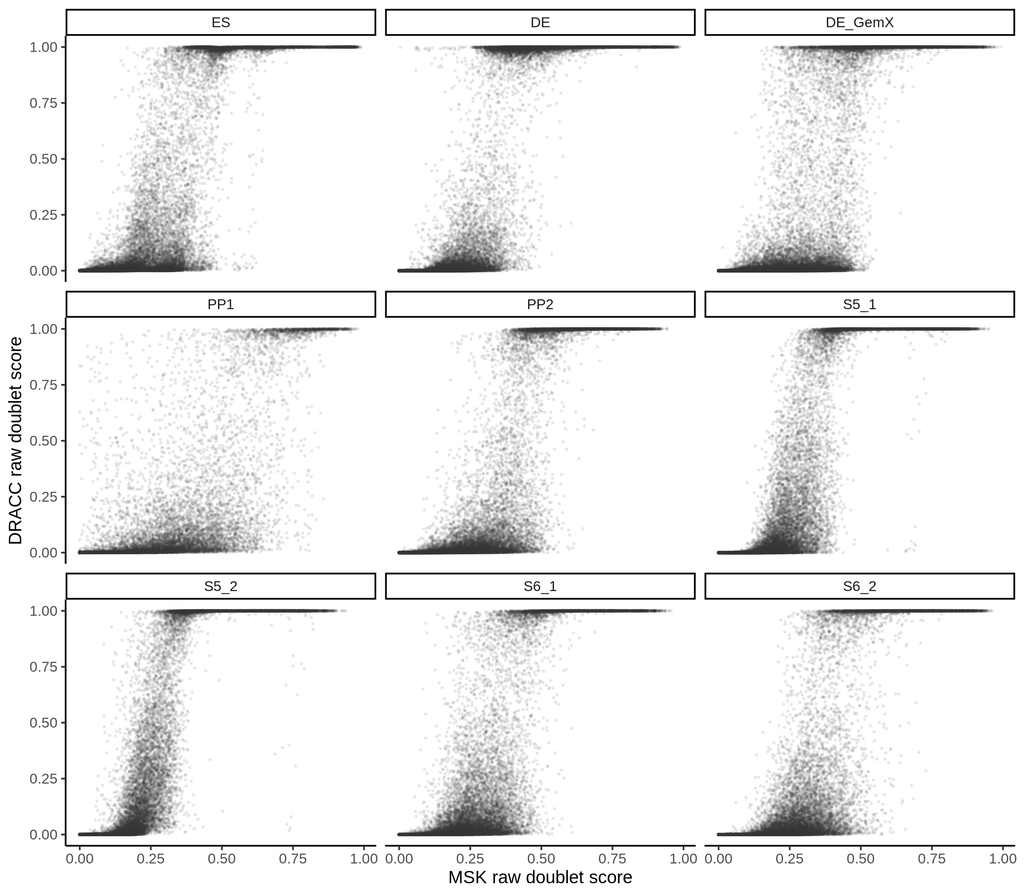

```r
doublet_data$stage = factor(doublet_data$stage, levels = stage_map$stage)
doublet_score_plot = ggplot(
  doublet_data,
  aes(x = msk_score, y = dracc_score)
) +
  geom_point(alpha = 0.08, size = 0.25, color = "#333333") +
  facet_wrap(~stage, ncol = 3) +
  labs(
    x = "MSK raw doublet score",
    y = "DRACC raw doublet score"
  ) +
  theme_classic(base_size = 10)

doublet_score_path = file.path(output_dir, "doublet_scores.png")
ggsave(
  doublet_score_path,
  doublet_score_plot,
  width = 8,
  height = 7,
  dpi = 300
)
knitr::include_graphics(doublet_score_path)
```

```r
# Adjust hypergeometric p-values in log space to avoid numerical underflow.
adjust_log_p <- function(log_p) {
  order_p = order(log_p)
  adjusted_sorted = log_p[order_p] +
    log(length(log_p) / seq_along(log_p))
  adjusted_sorted = rev(cummin(rev(adjusted_sorted)))
  adjusted = numeric(length(log_p))
  adjusted[order_p] = pmin(adjusted_sorted, 0)
  adjusted
}

doublet_enrichment = do.call(
  rbind,
  lapply(stage_map$stage, function(stage) {
    x = doublet_data[doublet_data$stage == stage, , drop = FALSE]
    n_cells = nrow(x)
    n_msk_doublet = sum(x$msk_call == "doublet")
    n_dracc_doublet = sum(x$dracc_call == "doublet")
    observed = sum(
      x$msk_call == "doublet" & x$dracc_call == "doublet"
    )
    expected = n_msk_doublet * n_dracc_doublet / n_cells

    data.frame(
      stage = stage,
      observed_doublet_overlap = observed,
      expected_doublet_overlap = expected,
      enrichment = observed / expected,
      log_p = phyper(
        observed - 1,
        n_msk_doublet,
        n_cells - n_msk_doublet,
        n_dracc_doublet,
        lower.tail = FALSE,
        log.p = TRUE
      ),
      stringsAsFactors = FALSE
    )
  })
)
doublet_enrichment$log_adjusted_p = adjust_log_p(
  doublet_enrichment$log_p
)
doublet_enrichment$log10_adjusted_p = (
  doublet_enrichment$log_adjusted_p / log(10)
)
doublet_enrichment$log_p = NULL
doublet_enrichment$log_adjusted_p = NULL

write.csv(
  doublet_enrichment,
  file.path(output_dir, "doublet_overlap_enrichment.csv"),
  row.names = FALSE
)

knitr::kable(
  doublet_enrichment,
  row.names = FALSE,
  digits = c(NA, 0, 1, 3, 1),
  col.names = c(
    "Stage", "Observed", "Expected", "Enrichment",
    "log10(BH-adjusted p)"
  )
)
```

| Stage | Observed | Expected | Enrichment | log10(BH-adjusted p) |
| --- | --- | --- | --- | --- |
| ES | 5002 | 1041.4 | 4.803 | -4014.6 |
| DE | 6719 | 1682.5 | 3.993 | -5291.3 |
| DE_GemX | 5688 | 1201.6 | 4.734 | -4276.7 |
| PP1 | 1214 | 254.6 | 4.768 | -810.9 |
| PP2 | 5021 | 1322.1 | 3.798 | -3582.4 |
| S5_1 | 4896 | 1182.3 | 4.141 | -3609.7 |
| S5_2 | 5356 | 1166.9 | 4.590 | -4309.9 |
| S6_1 | 3646 | 866.8 | 4.206 | -2491.3 |
| S6_2 | 3637 | 943.5 | 3.855 | -2396.8 |

## Transcriptome QC

The transcriptome-QC rules are applied cumulatively to each pipeline’s singlets: total RNA counts at least 200, detected genes at least 100, and mitochondrial percentage at most 20%. DRACC uses the same thresholds as MSK.

```r
stage_data = lapply(stage_data, function(x) {
  x$msk$pass_transcriptome_qc = (
    x$msk$pass_singlet &
      !is.na(x$msk$nCount_RNA) &
      x$msk$nCount_RNA >= 200 &
      !is.na(x$msk$nFeature_RNA) &
      x$msk$nFeature_RNA >= 100 &
      !is.na(x$msk$percent_mito) &
      x$msk$percent_mito <= 20
  )
  x$dracc$pass_transcriptome_qc = (
    x$dracc$pass_singlet &
      !is.na(x$dracc$total_counts) &
      x$dracc$total_counts >= 200 &
      !is.na(x$dracc$n_genes) &
      x$dracc$n_genes >= 100 &
      !is.na(x$dracc$mt_pct) &
      x$dracc$mt_pct <= 20
  )
  x
})

transcriptome_qc_table = do.call(
  rbind,
  lapply(stage_data, function(x) {
    compare_sets(
      x$stage,
      x$msk$barcode[x$msk$pass_transcriptome_qc],
      as.character(
        x$dracc$dracc_barcode[x$dracc$pass_transcriptome_qc]
      )
    )
  })
)
transcriptome_qc_table = add_overall(transcriptome_qc_table)

write.csv(
  transcriptome_qc_table,
  file.path(output_dir, "transcriptome_qc_cells.csv"),
  row.names = FALSE
)

knitr::kable(
  transcriptome_qc_table,
  row.names = FALSE,
  digits = c(NA, 0, 0, 0, 2, 2),
  col.names = c(
    "Stage", "MSK", "DRACC", "Shared",
    "Shared/MSK (%)", "Shared/DRACC (%)"
  )
)
```

| Stage | MSK | DRACC | Shared | Shared/MSK (%) | Shared/DRACC (%) |
| --- | --- | --- | --- | --- | --- |
| ES | 24646 | 25083 | 23901 | 96.98 | 95.29 |
| DE | 23049 | 23333 | 22215 | 96.38 | 95.21 |
| DE_GemX | 35905 | 34605 | 33312 | 92.78 | 96.26 |
| PP1 | 9674 | 10980 | 8988 | 92.91 | 81.86 |
| PP2 | 19642 | 20754 | 19123 | 97.36 | 92.14 |
| S5_1 | 22723 | 23702 | 21896 | 96.36 | 92.38 |
| S5_2 | 23338 | 24535 | 22849 | 97.90 | 93.13 |
| S6_1 | 15929 | 17385 | 15476 | 97.16 | 89.02 |
| S6_2 | 16729 | 18680 | 16116 | 96.34 | 86.27 |
| All | 191635 | 199057 | 183876 | 95.95 | 92.37 |

### Transcriptome-QC Diagnostics

The plots compare the raw QC values for cells called singlet by both pipelines. The diagonal marks equal values; dashed lines mark the applied thresholds.

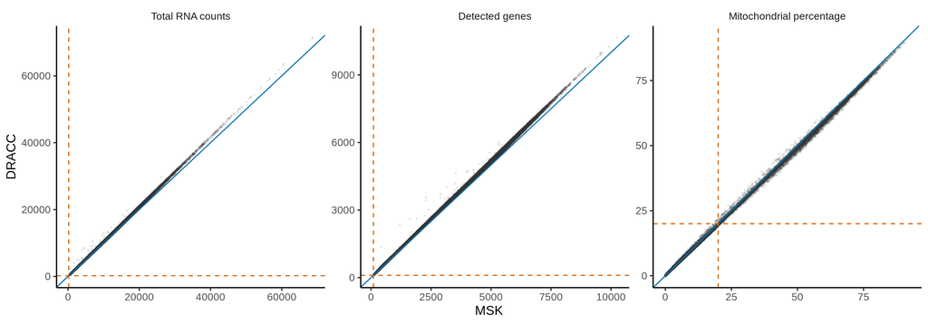

```r
# Align transcriptome-QC values for shared singlets.
paired_qc = do.call(
  rbind,
  lapply(stage_data, function(x) {
    shared_singlets = intersect(
      x$msk$barcode[x$msk$pass_singlet],
      as.character(x$dracc$dracc_barcode[x$dracc$pass_singlet])
    )
    msk_index = match(shared_singlets, x$msk$barcode)
    dracc_index = match(shared_singlets, x$dracc$dracc_barcode)

    data.frame(
      stage = x$stage,
      barcode = shared_singlets,
      msk_counts = as.numeric(x$msk$nCount_RNA[msk_index]),
      dracc_counts = as.numeric(x$dracc$total_counts[dracc_index]),
      msk_genes = as.numeric(x$msk$nFeature_RNA[msk_index]),
      dracc_genes = as.numeric(x$dracc$n_genes[dracc_index]),
      msk_mito = as.numeric(x$msk$percent_mito[msk_index]),
      dracc_mito = as.numeric(x$dracc$mt_pct[dracc_index]),
      stringsAsFactors = FALSE
    )
  })
)

metric_levels = c(
  "Total RNA counts",
  "Detected genes",
  "Mitochondrial percentage"
)
qc_plot_data = rbind(
  data.frame(
    metric = metric_levels[[1]],
    msk_value = paired_qc$msk_counts,
    dracc_value = paired_qc$dracc_counts
  ),
  data.frame(
    metric = metric_levels[[2]],
    msk_value = paired_qc$msk_genes,
    dracc_value = paired_qc$dracc_genes
  ),
  data.frame(
    metric = metric_levels[[3]],
    msk_value = paired_qc$msk_mito,
    dracc_value = paired_qc$dracc_mito
  )
)
qc_plot_data = qc_plot_data[
  complete.cases(qc_plot_data),
  ,
  drop = FALSE
]
qc_plot_data$metric = factor(qc_plot_data$metric, levels = metric_levels)

qc_thresholds = data.frame(
  metric = factor(metric_levels, levels = metric_levels),
  threshold = c(200, 100, 20)
)

transcriptome_qc_plot = ggplot(
  qc_plot_data,
  aes(x = msk_value, y = dracc_value)
) +
  geom_point(alpha = 0.08, size = 0.25, color = "#333333") +
  geom_abline(
    slope = 1,
    intercept = 0,
    linewidth = 0.4,
    color = "#0072B2"
  ) +
  geom_vline(
    data = qc_thresholds,
    aes(xintercept = threshold),
    linewidth = 0.4,
    linetype = 2,
    color = "#D55E00"
  ) +
  geom_hline(
    data = qc_thresholds,
    aes(yintercept = threshold),
    linewidth = 0.4,
    linetype = 2,
    color = "#D55E00"
  ) +
  facet_wrap(~metric, scales = "free", nrow = 1) +
  labs(
    x = "MSK",
    y = "DRACC"
  ) +
  theme_classic(base_size = 10) +
  theme(strip.background = element_blank())

transcriptome_qc_plot_path = file.path(
  output_dir,
  "transcriptome_qc_metrics.png"
)
ggsave(
  transcriptome_qc_plot_path,
  transcriptome_qc_plot,
  width = 10,
  height = 3.5,
  dpi = 300
)
knitr::include_graphics(transcriptome_qc_plot_path)
```

## geneBC and LARRY Eligibility

This final selection is cumulative: only transcriptome-QC-qualified cells can pass. The same rule is applied to both workflows:

- KO: geneBC Type 1, LARRY Type 1, and LARRY is assigned and not WT.
- WT: geneBC Type 3, LARRY Type 1, and LARRY is WT.

Type 1 requires a top feature count of at least 5 and a second/top ratio no greater than 0.5. Type 3 requires a top feature count below 5. This excludes Type-2 calls, weak or unassigned LARRY calls, and the conflicting combination of Type-1 geneBC with a WT LARRY barcode.

```r
type_1 = "Type 1: Max >=5 & 2nd/Max <= 0.5"
type_3 = "Type 3: Max < 5"

stage_data = lapply(stage_data, function(x) {
  # Align supplied MSK feature assignments to its transcriptome cells.
  msk_bc_index = match(x$msk$barcode, x$msk_bc$barcode)
  msk_gene_call = as.character(x$msk_bc$geneBC[msk_bc_index])
  msk_gene_category = as.character(
    x$msk_bc$geneBCCategory[msk_bc_index]
  )
  msk_larry_call = as.character(x$msk_bc$larryBC[msk_bc_index])
  msk_larry_category = as.character(
    x$msk_bc$larryBCCategory[msk_bc_index]
  )
  msk_larry_type = as.character(x$msk_bc$larryBC_type[msk_bc_index])

  msk_is_ko = (
    msk_gene_category == type_1 &
      msk_larry_category == type_1 &
      msk_larry_type != "WT"
  )
  msk_is_wt = (
    msk_gene_category == type_3 &
      msk_larry_category == type_1 &
      msk_larry_type == "WT"
  )
  msk_is_ko[is.na(msk_is_ko)] = FALSE
  msk_is_wt[is.na(msk_is_wt)] = FALSE

  x$msk$pass_feature_eligibility = (
    x$msk$pass_transcriptome_qc &
      (msk_is_ko | msk_is_wt)
  )
  stopifnot(all(grepl("\\.[0-9]+$", msk_gene_call[msk_is_ko])))
  x$msk$genotype_label = rep(NA_character_, nrow(x$msk))
  x$msk$genotype_label[msk_is_ko] = sub(
    "\\.[0-9]+$",
    "",
    msk_gene_call[msk_is_ko]
  )
  x$msk$genotype_label[msk_is_wt] = "WT"

  # MSK wraps each WT LARRY ID with its paired WTBC alias.
  x$msk$clone_id = msk_larry_call
  msk_wt_clone = !is.na(msk_larry_type) & msk_larry_type == "WT"
  stopifnot(all(grepl(
    "^WTBC[0-9]+_BC[0-9]+$",
    x$msk$clone_id[msk_wt_clone]
  )))
  x$msk$clone_id[msk_wt_clone] = sub(
    "^WTBC[0-9]+_",
    "",
    x$msk$clone_id[msk_wt_clone]
  )

  wt_larry_labels = sort(unique(as.character(
    x$msk_bc$larryBC[x$msk_bc$larryBC_type == "WT"]
  )))
  stopifnot(
    length(wt_larry_labels) == 12L,
    all(grepl("^WTBC[0-9]+_BC[0-9]+$", wt_larry_labels))
  )
  wt_larry_barcodes = sub("^WTBC[0-9]+_", "", wt_larry_labels)
  stopifnot(
    !anyDuplicated(wt_larry_barcodes),
    !any(x$msk_bc$larryBC %in% wt_larry_barcodes)
  )

  guide_total = x$dracc[[paste0(x$guide_prefix, "__num_umis")]]
  guide_top = x$dracc[[paste0(x$guide_prefix, "__feature1_count")]]
  guide_second = x$dracc[[paste0(x$guide_prefix, "__feature2_count")]]
  larry_top = x$dracc[[paste0(x$larry_prefix, "__feature1_count")]]
  larry_second = x$dracc[[paste0(x$larry_prefix, "__feature2_count")]]
  dracc_gene_call = as.character(
    x$dracc[[paste0(x$guide_prefix, "__feature_call")]]
  )
  dracc_larry_source = x$dracc[[
    paste0(x$larry_prefix, "__feature_call")
  ]]
  dracc_larry_call = as.character(dracc_larry_source)
  stopifnot(
    !anyNA(guide_total),
    !anyNA(guide_top),
    !anyNA(guide_second),
    !anyNA(larry_top),
    !anyNA(larry_second),
    !anyNA(dracc_gene_call),
    !anyNA(dracc_larry_call),
    is.factor(dracc_larry_source),
    all(wt_larry_barcodes %in% levels(dracc_larry_source))
  )

  dracc_gene_type_1 = (
    guide_top >= 5 & guide_second <= 0.5 * guide_top
  )
  dracc_gene_type_3 = guide_total > 0 & guide_top < 5
  dracc_larry_type_1 = (
    larry_top >= 5 & larry_second <= 0.5 * larry_top
  )
  stopifnot(
    !any(dracc_gene_type_1 & dracc_gene_call == ""),
    !any(dracc_larry_type_1 & dracc_larry_call == "")
  )

  dracc_larry_is_wt = dracc_larry_call %in% wt_larry_barcodes
  dracc_is_ko = (
    dracc_gene_type_1 &
      dracc_larry_type_1 &
      !dracc_larry_is_wt
  )
  dracc_is_wt = (
    dracc_gene_type_3 &
      dracc_larry_type_1 &
      dracc_larry_is_wt
  )

  x$dracc$pass_feature_eligibility = (
    x$dracc$pass_transcriptome_qc &
      (dracc_is_ko | dracc_is_wt)
  )
  x$dracc$genotype_label = rep(NA_character_, nrow(x$dracc))
  x$dracc$genotype_label[dracc_is_ko] = dracc_gene_call[dracc_is_ko]
  x$dracc$genotype_label[dracc_is_wt] = "WT"
  x$dracc$clone_id = dracc_larry_call

  stopifnot(
    any(x$msk$pass_transcriptome_qc & msk_is_wt),
    any(x$dracc$pass_transcriptome_qc & dracc_is_wt),
    !anyNA(
      x$msk$genotype_label[x$msk$pass_feature_eligibility]
    ),
    !anyNA(x$msk$clone_id[x$msk$pass_feature_eligibility]),
    !anyNA(
      x$dracc$genotype_label[x$dracc$pass_feature_eligibility]
    ),
    !anyNA(x$dracc$clone_id[x$dracc$pass_feature_eligibility])
  )
  x
})

feature_eligibility_table = do.call(
  rbind,
  lapply(stage_data, function(x) {
    compare_sets(
      x$stage,
      x$msk$barcode[x$msk$pass_feature_eligibility],
      as.character(
        x$dracc$dracc_barcode[x$dracc$pass_feature_eligibility]
      )
    )
  })
)
feature_eligibility_table = add_overall(feature_eligibility_table)

write.csv(
  feature_eligibility_table,
  file.path(output_dir, "feature_eligible_cells.csv"),
  row.names = FALSE
)

knitr::kable(
  feature_eligibility_table,
  row.names = FALSE,
  digits = c(NA, 0, 0, 0, 2, 2),
  col.names = c(
    "Stage", "MSK", "DRACC", "Shared",
    "Shared/MSK (%)", "Shared/DRACC (%)"
  )
)
```

| Stage | MSK | DRACC | Shared | Shared/MSK (%) | Shared/DRACC (%) |
| --- | --- | --- | --- | --- | --- |
| ES | 18932 | 20975 | 18301 | 96.67 | 87.25 |
| DE | 15554 | 16473 | 14955 | 96.15 | 90.78 |
| DE_GemX | 24256 | 24876 | 22605 | 93.19 | 90.87 |
| PP1 | 5247 | 5958 | 4851 | 92.45 | 81.42 |
| PP2 | 10141 | 11783 | 9886 | 97.49 | 83.90 |
| S5_1 | 11082 | 12559 | 10823 | 97.66 | 86.18 |
| S5_2 | 11332 | 12397 | 11033 | 97.36 | 89.00 |
| S6_1 | 7037 | 8195 | 6750 | 95.92 | 82.37 |
| S6_2 | 6987 | 8228 | 6741 | 96.48 | 81.93 |
| All | 110568 | 121444 | 105945 | 95.82 | 87.24 |

### Final Feature-Identity Agreement

Among cells retained by both workflows, downstream genotype labels are the target gene symbol for KO cells and `WT` for WT cells. MSK guide-number suffixes such as `.1` are removed. For WT clones, MSK’s `WTBC..._` wrapper is removed so both workflows use the native `BC...` LARRY identifier; all clone IDs are then compared exactly.

```r
feature_identity = do.call(
  rbind,
  lapply(stage_data, function(x) {
    shared_cells = intersect(
      x$msk$barcode[x$msk$pass_feature_eligibility],
      as.character(
        x$dracc$dracc_barcode[x$dracc$pass_feature_eligibility]
      )
    )
    msk_index = match(shared_cells, x$msk$barcode)
    dracc_index = match(shared_cells, x$dracc$dracc_barcode)

    data.frame(
      stage = x$stage,
      barcode = shared_cells,
      msk_genotype = x$msk$genotype_label[msk_index],
      dracc_genotype = x$dracc$genotype_label[dracc_index],
      msk_clone_id = x$msk$clone_id[msk_index],
      dracc_clone_id = x$dracc$clone_id[dracc_index],
      stringsAsFactors = FALSE
    )
  })
)
stopifnot(!anyNA(feature_identity))

# Summarize exact downstream identity agreement for one stage or all stages.
summarize_feature_identity <- function(x, stage) {
  n_cells = nrow(x)
  data.frame(
    stage = stage,
    n_shared = n_cells,
    genotype_matches = sum(x$msk_genotype == x$dracc_genotype),
    genotype_agreement = ifelse(
      n_cells > 0,
      100 * mean(x$msk_genotype == x$dracc_genotype),
      NA_real_
    ),
    clone_id_matches = sum(x$msk_clone_id == x$dracc_clone_id),
    clone_id_agreement = ifelse(
      n_cells > 0,
      100 * mean(x$msk_clone_id == x$dracc_clone_id),
      NA_real_
    ),
    stringsAsFactors = FALSE
  )
}

feature_identity_table = do.call(
  rbind,
  c(
    lapply(stage_map$stage, function(stage) {
      summarize_feature_identity(
        feature_identity[feature_identity$stage == stage, , drop = FALSE],
        stage
      )
    }),
    list(summarize_feature_identity(feature_identity, "All"))
  )
)

write.csv(
  feature_identity_table,
  file.path(output_dir, "feature_identity_agreement.csv"),
  row.names = FALSE
)

knitr::kable(
  feature_identity_table,
  row.names = FALSE,
  digits = c(NA, 0, 0, 2, 0, 2),
  col.names = c(
    "Stage", "Shared retained", "Genotype matches",
    "Genotype agreement (%)", "Clone-ID matches",
    "Clone-ID agreement (%)"
  )
)
```

| Stage | Shared retained | Genotype matches | Genotype agreement (%) | Clone-ID matches | Clone-ID agreement (%) |
| --- | --- | --- | --- | --- | --- |
| ES | 18301 | 18301 | 100.00 | 18190 | 99.39 |
| DE | 14955 | 14955 | 100.00 | 14777 | 98.81 |
| DE_GemX | 22605 | 22602 | 99.99 | 22328 | 98.77 |
| PP1 | 4851 | 4844 | 99.86 | 4840 | 99.77 |
| PP2 | 9886 | 9875 | 99.89 | 9873 | 99.87 |
| S5_1 | 10823 | 10821 | 99.98 | 10799 | 99.78 |
| S5_2 | 11033 | 11031 | 99.98 | 11015 | 99.84 |
| S6_1 | 6750 | 6743 | 99.90 | 6744 | 99.91 |
| S6_2 | 6741 | 6728 | 99.81 | 6739 | 99.97 |
| All | 105945 | 105900 | 99.96 | 105305 | 99.40 |

## Overall Summary

This table reports the cumulative consequence of each cell-selection step.

```r
summary_steps = list(
  "Initial called cells" = initial_table,
  "Singlets" = singlet_table,
  "Transcriptome QC" = transcriptome_qc_table,
  "geneBC/LARRY eligible" = feature_eligibility_table
)

overall_summary = do.call(
  rbind,
  lapply(names(summary_steps), function(step) {
    x = summary_steps[[step]]
    x = x[x$stage == "All", , drop = FALSE]

    data.frame(
      step = step,
      n_msk = x$n_msk,
      n_dracc = x$n_dracc,
      n_shared = x$n_shared,
      shared_over_msk = x$shared_over_msk,
      shared_over_dracc = x$shared_over_dracc,
      stringsAsFactors = FALSE
    )
  })
)

write.csv(
  overall_summary,
  file.path(output_dir, "overall_summary.csv"),
  row.names = FALSE
)

knitr::kable(
  overall_summary,
  row.names = FALSE,
  digits = c(NA, 0, 0, 0, 2, 2),
  col.names = c(
    "Step", "MSK", "DRACC", "Shared",
    "Shared/MSK (%)", "Shared/DRACC (%)"
  )
)
```

| Step | MSK | DRACC | Shared | Shared/MSK (%) | Shared/DRACC (%) |
| --- | --- | --- | --- | --- | --- |
| Initial called cells | 260440 | 260228 | 252999 | 97.14 | 97.22 |
| Singlets | 209583 | 212386 | 195493 | 93.28 | 92.05 |
| Transcriptome QC | 191635 | 199057 | 183876 | 95.95 | 92.37 |
| geneBC/LARRY eligible | 110568 | 121444 | 105945 | 95.82 | 87.24 |